# Risk Factor Analysis

## Outcome Variable

**Outcome Variable:** ever_stunted

## Predictor Variables

**Intervention Variable:** hhwealth_quart

**Adjustment Set:**

- arm
- sex
- W_mage
- meducyrs
- feducyrs
- W_gagebrth
- W_birthwt
- W_birthlen
- W_nchldlt5
- W_parity
- delta_W_mage
- delta_meducyrs
- delta_feducyrs
- delta_W_gagebrth
- delta_W_birthwt
- delta_W_birthlen
- delta_W_nchldlt5
- delta_W_parity

## Stratifying Variables

The analysis was stratified on these variable(s):

- agecat
- studyid
- country

## Data Summary

| agecat | studyid | country | hhwealth_quart | ever_stunted | n_cell | n |
| --- | --- | --- | --- | --- | --- | --- |
| 0-24 months | ki0047075b-MAL-ED | BANGLADESH | Wealth Q4 | 0 | 7 | 82 |
| 0-24 months | ki0047075b-MAL-ED | BANGLADESH | Wealth Q4 | 1 | 14 | 82 |
| 0-24 months | ki0047075b-MAL-ED | BANGLADESH | Wealth Q1 | 0 | 6 | 82 |
| 0-24 months | ki0047075b-MAL-ED | BANGLADESH | Wealth Q1 | 1 | 15 | 82 |
| 0-24 months | ki0047075b-MAL-ED | BANGLADESH | Wealth Q2 | 0 | 8 | 82 |
| 0-24 months | ki0047075b-MAL-ED | BANGLADESH | Wealth Q2 | 1 | 12 | 82 |
| 0-24 months | ki0047075b-MAL-ED | BANGLADESH | Wealth Q3 | 0 | 8 | 82 |
| 0-24 months | ki0047075b-MAL-ED | BANGLADESH | Wealth Q3 | 1 | 12 | 82 |
| 0-24 months | ki0047075b-MAL-ED | INDIA | Wealth Q4 | 0 | 6 | 71 |
| 0-24 months | ki0047075b-MAL-ED | INDIA | Wealth Q4 | 1 | 12 | 71 |
| 0-24 months | ki0047075b-MAL-ED | INDIA | Wealth Q1 | 0 | 9 | 71 |
| 0-24 months | ki0047075b-MAL-ED | INDIA | Wealth Q1 | 1 | 10 | 71 |
| 0-24 months | ki0047075b-MAL-ED | INDIA | Wealth Q2 | 0 | 10 | 71 |
| 0-24 months | ki0047075b-MAL-ED | INDIA | Wealth Q2 | 1 | 7 | 71 |
| 0-24 months | ki0047075b-MAL-ED | INDIA | Wealth Q3 | 0 | 4 | 71 |
| 0-24 months | ki0047075b-MAL-ED | INDIA | Wealth Q3 | 1 | 13 | 71 |
| 0-24 months | ki0047075b-MAL-ED | NEPAL | Wealth Q4 | 0 | 4 | 42 |
| 0-24 months | ki0047075b-MAL-ED | NEPAL | Wealth Q4 | 1 | 7 | 42 |
| 0-24 months | ki0047075b-MAL-ED | NEPAL | Wealth Q1 | 0 | 6 | 42 |
| 0-24 months | ki0047075b-MAL-ED | NEPAL | Wealth Q1 | 1 | 5 | 42 |
| 0-24 months | ki0047075b-MAL-ED | NEPAL | Wealth Q2 | 0 | 4 | 42 |
| 0-24 months | ki0047075b-MAL-ED | NEPAL | Wealth Q2 | 1 | 6 | 42 |
| 0-24 months | ki0047075b-MAL-ED | NEPAL | Wealth Q3 | 0 | 6 | 42 |
| 0-24 months | ki0047075b-MAL-ED | NEPAL | Wealth Q3 | 1 | 4 | 42 |
| 0-24 months | ki0047075b-MAL-ED | PERU | Wealth Q4 | 0 | 2 | 37 |
| 0-24 months | ki0047075b-MAL-ED | PERU | Wealth Q4 | 1 | 8 | 37 |
| 0-24 months | ki0047075b-MAL-ED | PERU | Wealth Q1 | 0 | 2 | 37 |
| 0-24 months | ki0047075b-MAL-ED | PERU | Wealth Q1 | 1 | 7 | 37 |
| 0-24 months | ki0047075b-MAL-ED | PERU | Wealth Q2 | 0 | 0 | 37 |
| 0-24 months | ki0047075b-MAL-ED | PERU | Wealth Q2 | 1 | 9 | 37 |

[output cut: 378 more lines]

The following strata were considered:

- agecat: 0-24 months, studyid: ki0047075b-MAL-ED, country: BANGLADESH
- agecat: 0-24 months, studyid: ki0047075b-MAL-ED, country: INDIA
- agecat: 0-24 months, studyid: ki0047075b-MAL-ED, country: NEPAL
- agecat: 0-24 months, studyid: ki0047075b-MAL-ED, country: PERU
- agecat: 0-24 months, studyid: ki0047075b-MAL-ED, country: SOUTH AFRICA
- agecat: 0-24 months, studyid: ki0047075b-MAL-ED, country: TANZANIA, UNITED REPUBLIC OF
- agecat: 0-24 months, studyid: ki1000108-CMC-V-BCS-2002, country: INDIA
- agecat: 0-24 months, studyid: ki1000108-IRC, country: INDIA
- agecat: 0-24 months, studyid: ki1017093b-PROVIDE, country: BANGLADESH
- agecat: 0-24 months, studyid: ki1066203-TanzaniaChild2, country: TANZANIA, UNITED REPUBLIC OF
- agecat: 0-24 months, studyid: ki1113344-GMS-Nepal, country: NEPAL
- agecat: 0-24 months, studyid: ki1114097-CONTENT, country: PERU
- agecat: 0-24 months, studyid: ki1135781-COHORTS, country: GUATEMALA
- agecat: 0-24 months, studyid: ki1135781-COHORTS, country: PHILIPPINES
- agecat: 0-24 months, studyid: ki1148112-LCNI-5, country: MALAWI
- agecat: 0-24 months, studyid: kiGH5241-JiVitA-3, country: BANGLADESH
- agecat: 0-24 months, studyid: kiGH5241-JiVitA-4, country: BANGLADESH
- agecat: 0-6 months, studyid: ki0047075b-MAL-ED, country: BANGLADESH
- agecat: 0-6 months, studyid: ki0047075b-MAL-ED, country: INDIA
- agecat: 0-6 months, studyid: ki0047075b-MAL-ED, country: NEPAL
- agecat: 0-6 months, studyid: ki0047075b-MAL-ED, country: PERU
- agecat: 0-6 months, studyid: ki0047075b-MAL-ED, country: SOUTH AFRICA
- agecat: 0-6 months, studyid: ki0047075b-MAL-ED, country: TANZANIA, UNITED REPUBLIC OF
- agecat: 0-6 months, studyid: ki1000108-CMC-V-BCS-2002, country: INDIA
- agecat: 0-6 months, studyid: ki1000108-IRC, country: INDIA
- agecat: 0-6 months, studyid: ki1017093b-PROVIDE, country: BANGLADESH
- agecat: 0-6 months, studyid: ki1066203-TanzaniaChild2, country: TANZANIA, UNITED REPUBLIC OF
- agecat: 0-6 months, studyid: ki1113344-GMS-Nepal, country: NEPAL
- agecat: 0-6 months, studyid: ki1114097-CONTENT, country: PERU
- agecat: 0-6 months, studyid: ki1135781-COHORTS, country: GUATEMALA
- agecat: 0-6 months, studyid: ki1135781-COHORTS, country: PHILIPPINES
- agecat: 0-6 months, studyid: ki1148112-LCNI-5, country: MALAWI
- agecat: 0-6 months, studyid: kiGH5241-JiVitA-3, country: BANGLADESH
- agecat: 0-6 months, studyid: kiGH5241-JiVitA-4, country: BANGLADESH
- agecat: 6-24 months, studyid: ki0047075b-MAL-ED, country: BANGLADESH
- agecat: 6-24 months, studyid: ki0047075b-MAL-ED, country: INDIA
- agecat: 6-24 months, studyid: ki0047075b-MAL-ED, country: NEPAL
- agecat: 6-24 months, studyid: ki0047075b-MAL-ED, country: PERU
- agecat: 6-24 months, studyid: ki0047075b-MAL-ED, country: SOUTH AFRICA
- agecat: 6-24 months, studyid: ki0047075b-MAL-ED, country: TANZANIA, UNITED REPUBLIC OF
- agecat: 6-24 months, studyid: ki1000108-CMC-V-BCS-2002, country: INDIA
- agecat: 6-24 months, studyid: ki1000108-IRC, country: INDIA
- agecat: 6-24 months, studyid: ki1017093b-PROVIDE, country: BANGLADESH
- agecat: 6-24 months, studyid: ki1066203-TanzaniaChild2, country: TANZANIA, UNITED REPUBLIC OF
- agecat: 6-24 months, studyid: ki1113344-GMS-Nepal, country: NEPAL
- agecat: 6-24 months, studyid: ki1114097-CONTENT, country: PERU
- agecat: 6-24 months, studyid: ki1135781-COHORTS, country: GUATEMALA
- agecat: 6-24 months, studyid: ki1135781-COHORTS, country: PHILIPPINES
- agecat: 6-24 months, studyid: ki1148112-LCNI-5, country: MALAWI
- agecat: 6-24 months, studyid: kiGH5241-JiVitA-3, country: BANGLADESH
- agecat: 6-24 months, studyid: kiGH5241-JiVitA-4, country: BANGLADESH

### Dropped Strata

Some strata were dropped due to rare outcomes:

- agecat: 0-24 months, studyid: ki0047075b-MAL-ED, country: INDIA
- agecat: 0-24 months, studyid: ki0047075b-MAL-ED, country: NEPAL
- agecat: 0-24 months, studyid: ki0047075b-MAL-ED, country: PERU
- agecat: 0-24 months, studyid: ki0047075b-MAL-ED, country: TANZANIA, UNITED REPUBLIC OF
- agecat: 0-6 months, studyid: ki0047075b-MAL-ED, country: BANGLADESH
- agecat: 0-6 months, studyid: ki0047075b-MAL-ED, country: NEPAL
- agecat: 0-6 months, studyid: ki0047075b-MAL-ED, country: PERU
- agecat: 0-6 months, studyid: ki0047075b-MAL-ED, country: SOUTH AFRICA
- agecat: 0-6 months, studyid: ki0047075b-MAL-ED, country: TANZANIA, UNITED REPUBLIC OF
- agecat: 6-24 months, studyid: ki0047075b-MAL-ED, country: BANGLADESH
- agecat: 6-24 months, studyid: ki0047075b-MAL-ED, country: INDIA
- agecat: 6-24 months, studyid: ki0047075b-MAL-ED, country: NEPAL
- agecat: 6-24 months, studyid: ki0047075b-MAL-ED, country: PERU
- agecat: 6-24 months, studyid: ki0047075b-MAL-ED, country: SOUTH AFRICA
- agecat: 6-24 months, studyid: ki0047075b-MAL-ED, country: TANZANIA, UNITED REPUBLIC OF
- agecat: 6-24 months, studyid: ki1114097-CONTENT, country: PERU

## Methods Detail

We’re interested in the causal parameters $E[Y_a]$ for all values of $a \in \mathcal{A}$. These parameters represent the mean outcome if, possibly contrary to fact, we intervened to set all units to have $A=a$. Under the randomization and positivity assumptions, these are identified by the statistical parameters $\psi_a=E_W[E_{Y|A,W}(Y|A=a,W)]$. In addition, we’re interested in the mean of $Y$, $E[Y]$ under no intervention (the observed mean). We will estimate these parameters by using SuperLearner to fit the relevant likelihood factors – $E_{Y|A,W}(Y|A=a,W)$ and $p(A=a|W)$, and then updating our likelihood fit using a joint TMLE.

For unadjusted analyses ($W=\{\}$), initial likelihoods were estimated using Lrnr_glm to estimate the simple $E(Y|A)$ and Lrnr_mean to estimate $p(A)$. For adjusted analyses, a small library containing Lrnr_glmnet, Lrnr_xgboost, and Lrnr_mean was used.

Having estimated these parameters, we will then use the delta method to estimate relative risks and attributable risks relative to a prespecified baseline level of $A$.

# Results Detail

## Results Plots

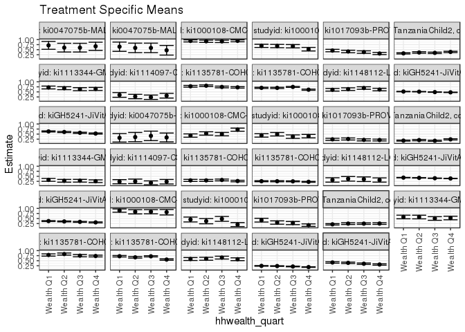

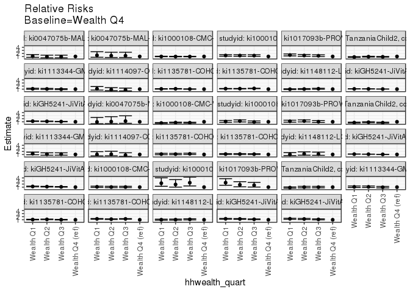

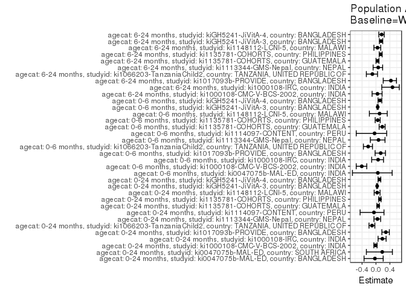

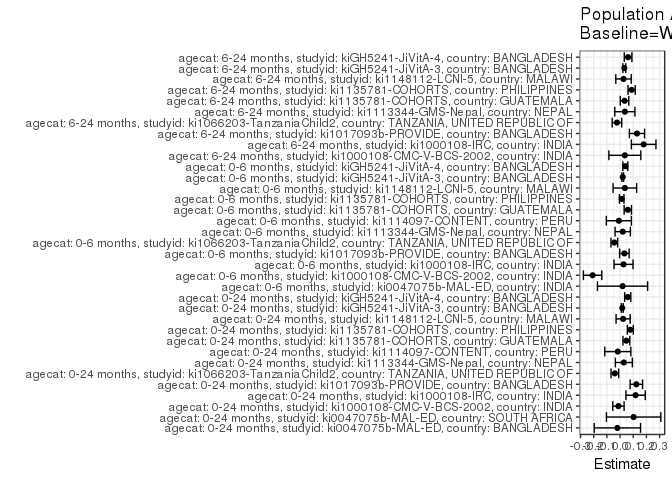

## Results Table

### Parameter: TSM

| agecat | studyid | country | intervention_level | baseline_level | estimate | ci_lower | ci_upper |
| --- | --- | --- | --- | --- | --- | --- | --- |
| 0-24 months | ki0047075b-MAL-ED | BANGLADESH | Wealth Q4 | NA | 0.6666667 | 0.4638066 | 0.8695268 |
| 0-24 months | ki0047075b-MAL-ED | BANGLADESH | Wealth Q1 | NA | 0.7142857 | 0.5198819 | 0.9086895 |
| 0-24 months | ki0047075b-MAL-ED | BANGLADESH | Wealth Q2 | NA | 0.6000000 | 0.3839754 | 0.8160246 |
| 0-24 months | ki0047075b-MAL-ED | BANGLADESH | Wealth Q3 | NA | 0.6000000 | 0.3839754 | 0.8160246 |
| 0-24 months | ki0047075b-MAL-ED | SOUTH AFRICA | Wealth Q4 | NA | 0.4705882 | 0.2315552 | 0.7096213 |
| 0-24 months | ki0047075b-MAL-ED | SOUTH AFRICA | Wealth Q1 | NA | 0.6470588 | 0.4182021 | 0.8759156 |
| 0-24 months | ki0047075b-MAL-ED | SOUTH AFRICA | Wealth Q2 | NA | 0.5882353 | 0.3525455 | 0.8239251 |
| 0-24 months | ki0047075b-MAL-ED | SOUTH AFRICA | Wealth Q3 | NA | 0.5882353 | 0.3525455 | 0.8239251 |
| 0-24 months | ki1000108-CMC-V-BCS-2002 | INDIA | Wealth Q4 | NA | 0.9375000 | 0.8890135 | 0.9859865 |
| 0-24 months | ki1000108-CMC-V-BCS-2002 | INDIA | Wealth Q1 | NA | 0.9340659 | 0.8830091 | 0.9851228 |
| 0-24 months | ki1000108-CMC-V-BCS-2002 | INDIA | Wealth Q2 | NA | 0.9157895 | 0.8598717 | 0.9717073 |
| 0-24 months | ki1000108-CMC-V-BCS-2002 | INDIA | Wealth Q3 | NA | 0.9120879 | 0.8538303 | 0.9703456 |
| 0-24 months | ki1000108-IRC | INDIA | Wealth Q4 | NA | 0.5236985 | 0.4356498 | 0.6117472 |
| 0-24 months | ki1000108-IRC | INDIA | Wealth Q1 | NA | 0.6884409 | 0.6092208 | 0.7676609 |
| 0-24 months | ki1000108-IRC | INDIA | Wealth Q2 | NA | 0.6796534 | 0.5977450 | 0.7615619 |
| 0-24 months | ki1000108-IRC | INDIA | Wealth Q3 | NA | 0.6706080 | 0.5875854 | 0.7536305 |
| 0-24 months | ki1017093b-PROVIDE | BANGLADESH | Wealth Q4 | NA | 0.3105861 | 0.2562632 | 0.3649090 |
| 0-24 months | ki1017093b-PROVIDE | BANGLADESH | Wealth Q1 | NA | 0.4567006 | 0.3957073 | 0.5176940 |
| 0-24 months | ki1017093b-PROVIDE | BANGLADESH | Wealth Q2 | NA | 0.4086220 | 0.3464476 | 0.4707965 |
| 0-24 months | ki1017093b-PROVIDE | BANGLADESH | Wealth Q3 | NA | 0.3807383 | 0.3188035 | 0.4426731 |
| 0-24 months | ki1066203-TanzaniaChild2 | TANZANIA, UNITED REPUBLIC OF | Wealth Q4 | NA | 0.3864487 | 0.3522856 | 0.4206119 |
| 0-24 months | ki1066203-TanzaniaChild2 | TANZANIA, UNITED REPUBLIC OF | Wealth Q1 | NA | 0.3164558 | 0.2862138 | 0.3466978 |
| 0-24 months | ki1066203-TanzaniaChild2 | TANZANIA, UNITED REPUBLIC OF | Wealth Q2 | NA | 0.3604956 | 0.3236670 | 0.3973242 |
| 0-24 months | ki1066203-TanzaniaChild2 | TANZANIA, UNITED REPUBLIC OF | Wealth Q3 | NA | 0.3425507 | 0.3082302 | 0.3768711 |
| 0-24 months | ki1113344-GMS-Nepal | NEPAL | Wealth Q4 | NA | 0.6457306 | 0.5707114 | 0.7207498 |
| 0-24 months | ki1113344-GMS-Nepal | NEPAL | Wealth Q1 | NA | 0.7171581 | 0.6472282 | 0.7870880 |
| 0-24 months | ki1113344-GMS-Nepal | NEPAL | Wealth Q2 | NA | 0.6833144 | 0.6102482 | 0.7563805 |
| 0-24 months | ki1113344-GMS-Nepal | NEPAL | Wealth Q3 | NA | 0.6339414 | 0.5587674 | 0.7091153 |
| 0-24 months | ki1114097-CONTENT | PERU | Wealth Q4 | NA | 0.3101929 | 0.1929809 | 0.4274049 |
| 0-24 months | ki1114097-CONTENT | PERU | Wealth Q1 | NA | 0.3488276 | 0.2318850 | 0.4657702 |

[output cut: 110 more lines]

### Parameter: E(Y)

| agecat | studyid | country | intervention_level | baseline_level | estimate | ci_lower | ci_upper |
| --- | --- | --- | --- | --- | --- | --- | --- |
| 0-24 months | ki0047075b-MAL-ED | BANGLADESH | NA | NA | 0.6463415 | 0.5422228 | 0.7504601 |
| 0-24 months | ki0047075b-MAL-ED | SOUTH AFRICA | NA | NA | 0.5735294 | 0.4551072 | 0.6919516 |
| 0-24 months | ki1000108-CMC-V-BCS-2002 | INDIA | NA | NA | 0.9249330 | 0.8981563 | 0.9517096 |
| 0-24 months | ki1000108-IRC | INDIA | NA | NA | 0.6414634 | 0.5949863 | 0.6879405 |
| 0-24 months | ki1017093b-PROVIDE | BANGLADESH | NA | NA | 0.4340974 | 0.3973018 | 0.4708930 |
| 0-24 months | ki1066203-TanzaniaChild2 | TANZANIA, UNITED REPUBLIC OF | NA | NA | 0.3468960 | 0.3277853 | 0.3660067 |
| 0-24 months | ki1113344-GMS-Nepal | NEPAL | NA | NA | 0.6744186 | 0.6369554 | 0.7118819 |
| 0-24 months | ki1114097-CONTENT | PERU | NA | NA | 0.2930233 | 0.2320422 | 0.3540043 |
| 0-24 months | ki1135781-COHORTS | GUATEMALA | NA | NA | 0.7715180 | 0.7484902 | 0.7945458 |
| 0-24 months | ki1135781-COHORTS | PHILIPPINES | NA | NA | 0.6866209 | 0.6701747 | 0.7030670 |
| 0-24 months | ki1148112-LCNI-5 | MALAWI | NA | NA | 0.6376989 | 0.6047193 | 0.6706785 |
| 0-24 months | kiGH5241-JiVitA-3 | BANGLADESH | NA | NA | 0.4940863 | 0.4862363 | 0.5019363 |
| 0-24 months | kiGH5241-JiVitA-4 | BANGLADESH | NA | NA | 0.5844710 | 0.5684819 | 0.6004601 |
| 0-6 months | ki0047075b-MAL-ED | INDIA | NA | NA | 0.3521127 | 0.2402231 | 0.4640023 |
| 0-6 months | ki1000108-CMC-V-BCS-2002 | INDIA | NA | NA | 0.5108696 | 0.4597270 | 0.5620121 |
| 0-6 months | ki1000108-IRC | INDIA | NA | NA | 0.4243902 | 0.3764905 | 0.4722900 |
| 0-6 months | ki1017093b-PROVIDE | BANGLADESH | NA | NA | 0.2392550 | 0.2075826 | 0.2709275 |
| 0-6 months | ki1066203-TanzaniaChild2 | TANZANIA, UNITED REPUBLIC OF | NA | NA | 0.1950503 | 0.1791413 | 0.2109594 |
| 0-6 months | ki1113344-GMS-Nepal | NEPAL | NA | NA | 0.2774086 | 0.2416141 | 0.3132032 |
| 0-6 months | ki1114097-CONTENT | PERU | NA | NA | 0.2232558 | 0.1674626 | 0.2790491 |
| 0-6 months | ki1135781-COHORTS | GUATEMALA | NA | NA | 0.3240116 | 0.2955133 | 0.3525098 |
| 0-6 months | ki1135781-COHORTS | PHILIPPINES | NA | NA | 0.2391233 | 0.2240003 | 0.2542464 |
| 0-6 months | ki1148112-LCNI-5 | MALAWI | NA | NA | 0.3531599 | 0.2959376 | 0.4103821 |
| 0-6 months | kiGH5241-JiVitA-3 | BANGLADESH | NA | NA | 0.4108893 | 0.4034376 | 0.4183410 |
| 0-6 months | kiGH5241-JiVitA-4 | BANGLADESH | NA | NA | 0.3474692 | 0.3322601 | 0.3626783 |
| 6-24 months | ki1000108-CMC-V-BCS-2002 | INDIA | NA | NA | 0.8486486 | 0.7968646 | 0.9004327 |
| 6-24 months | ki1000108-IRC | INDIA | NA | NA | 0.3771186 | 0.3151523 | 0.4390850 |
| 6-24 months | ki1017093b-PROVIDE | BANGLADESH | NA | NA | 0.2989011 | 0.2567922 | 0.3410100 |
| 6-24 months | ki1066203-TanzaniaChild2 | TANZANIA, UNITED REPUBLIC OF | NA | NA | 0.2268170 | 0.2062654 | 0.2473687 |
| 6-24 months | ki1113344-GMS-Nepal | NEPAL | NA | NA | 0.5610329 | 0.5138522 | 0.6082135 |
| 6-24 months | ki1135781-COHORTS | GUATEMALA | NA | NA | 0.7665094 | 0.7380190 | 0.7949999 |
| 6-24 months | ki1135781-COHORTS | PHILIPPINES | NA | NA | 0.6449788 | 0.6246093 | 0.6653483 |
| 6-24 months | ki1148112-LCNI-5 | MALAWI | NA | NA | 0.6000000 | 0.5639396 | 0.6360604 |
| 6-24 months | kiGH5241-JiVitA-3 | BANGLADESH | NA | NA | 0.2169852 | 0.2076274 | 0.2263430 |
| 6-24 months | kiGH5241-JiVitA-4 | BANGLADESH | NA | NA | 0.3735682 | 0.3548662 | 0.3922701 |

### Parameter: RR

| agecat | studyid | country | intervention_level | baseline_level | estimate | ci_lower | ci_upper |
| --- | --- | --- | --- | --- | --- | --- | --- |
| 0-24 months | ki0047075b-MAL-ED | BANGLADESH | Wealth Q4 | Wealth Q4 | 1.0000000 | 1.0000000 | 1.0000000 |
| 0-24 months | ki0047075b-MAL-ED | BANGLADESH | Wealth Q1 | Wealth Q4 | 1.0714286 | 0.7123007 | 1.6116217 |
| 0-24 months | ki0047075b-MAL-ED | BANGLADESH | Wealth Q2 | Wealth Q4 | 0.9000000 | 0.5617127 | 1.4420183 |
| 0-24 months | ki0047075b-MAL-ED | BANGLADESH | Wealth Q3 | Wealth Q4 | 0.9000000 | 0.5617127 | 1.4420183 |
| 0-24 months | ki0047075b-MAL-ED | SOUTH AFRICA | Wealth Q4 | Wealth Q4 | 1.0000000 | 1.0000000 | 1.0000000 |
| 0-24 months | ki0047075b-MAL-ED | SOUTH AFRICA | Wealth Q1 | Wealth Q4 | 1.3750000 | 0.7404481 | 2.5533526 |
| 0-24 months | ki0047075b-MAL-ED | SOUTH AFRICA | Wealth Q2 | Wealth Q4 | 1.2500000 | 0.6545492 | 2.3871392 |
| 0-24 months | ki0047075b-MAL-ED | SOUTH AFRICA | Wealth Q3 | Wealth Q4 | 1.2500000 | 0.6545492 | 2.3871392 |
| 0-24 months | ki1000108-CMC-V-BCS-2002 | INDIA | Wealth Q4 | Wealth Q4 | 1.0000000 | 1.0000000 | 1.0000000 |
| 0-24 months | ki1000108-CMC-V-BCS-2002 | INDIA | Wealth Q1 | Wealth Q4 | 0.9963370 | 0.9241135 | 1.0742051 |
| 0-24 months | ki1000108-CMC-V-BCS-2002 | INDIA | Wealth Q2 | Wealth Q4 | 0.9768421 | 0.9017212 | 1.0582212 |
| 0-24 months | ki1000108-CMC-V-BCS-2002 | INDIA | Wealth Q3 | Wealth Q4 | 0.9728938 | 0.8961328 | 1.0562300 |
| 0-24 months | ki1000108-IRC | INDIA | Wealth Q4 | Wealth Q4 | 1.0000000 | 1.0000000 | 1.0000000 |
| 0-24 months | ki1000108-IRC | INDIA | Wealth Q1 | Wealth Q4 | 1.3145747 | 1.0794534 | 1.6009091 |
| 0-24 months | ki1000108-IRC | INDIA | Wealth Q2 | Wealth Q4 | 1.2977952 | 1.0617997 | 1.5862431 |
| 0-24 months | ki1000108-IRC | INDIA | Wealth Q3 | Wealth Q4 | 1.2805229 | 1.0452275 | 1.5687867 |
| 0-24 months | ki1017093b-PROVIDE | BANGLADESH | Wealth Q4 | Wealth Q4 | 1.0000000 | 1.0000000 | 1.0000000 |
| 0-24 months | ki1017093b-PROVIDE | BANGLADESH | Wealth Q1 | Wealth Q4 | 1.4704477 | 1.1927447 | 1.8128075 |
| 0-24 months | ki1017093b-PROVIDE | BANGLADESH | Wealth Q2 | Wealth Q4 | 1.3156482 | 1.0554203 | 1.6400387 |
| 0-24 months | ki1017093b-PROVIDE | BANGLADESH | Wealth Q3 | Wealth Q4 | 1.2258704 | 0.9765736 | 1.5388068 |
| 0-24 months | ki1066203-TanzaniaChild2 | TANZANIA, UNITED REPUBLIC OF | Wealth Q4 | Wealth Q4 | 1.0000000 | 1.0000000 | 1.0000000 |
| 0-24 months | ki1066203-TanzaniaChild2 | TANZANIA, UNITED REPUBLIC OF | Wealth Q1 | Wealth Q4 | 0.8188817 | 0.7208188 | 0.9302854 |
| 0-24 months | ki1066203-TanzaniaChild2 | TANZANIA, UNITED REPUBLIC OF | Wealth Q2 | Wealth Q4 | 0.9328421 | 0.8168875 | 1.0652560 |
| 0-24 months | ki1066203-TanzaniaChild2 | TANZANIA, UNITED REPUBLIC OF | Wealth Q3 | Wealth Q4 | 0.8864065 | 0.7773104 | 1.0108144 |
| 0-24 months | ki1113344-GMS-Nepal | NEPAL | Wealth Q4 | Wealth Q4 | 1.0000000 | 1.0000000 | 1.0000000 |
| 0-24 months | ki1113344-GMS-Nepal | NEPAL | Wealth Q1 | Wealth Q4 | 1.1106151 | 0.9543283 | 1.2924963 |
| 0-24 months | ki1113344-GMS-Nepal | NEPAL | Wealth Q2 | Wealth Q4 | 1.0582035 | 0.9036609 | 1.2391756 |
| 0-24 months | ki1113344-GMS-Nepal | NEPAL | Wealth Q3 | Wealth Q4 | 0.9817428 | 0.8316096 | 1.1589800 |
| 0-24 months | ki1114097-CONTENT | PERU | Wealth Q4 | Wealth Q4 | 1.0000000 | 1.0000000 | 1.0000000 |
| 0-24 months | ki1114097-CONTENT | PERU | Wealth Q1 | Wealth Q4 | 1.1245506 | 0.6859964 | 1.8434705 |

[output cut: 110 more lines]

### Parameter: PAR

| agecat | studyid | country | intervention_level | baseline_level | estimate | ci_lower | ci_upper |
| --- | --- | --- | --- | --- | --- | --- | --- |
| 0-24 months | ki0047075b-MAL-ED | BANGLADESH | Wealth Q4 | NA | -0.0203252 | -0.1961517 | 0.1555013 |
| 0-24 months | ki0047075b-MAL-ED | SOUTH AFRICA | Wealth Q4 | NA | 0.1029412 | -0.1034377 | 0.3093200 |
| 0-24 months | ki1000108-CMC-V-BCS-2002 | INDIA | Wealth Q4 | NA | -0.0125670 | -0.0556692 | 0.0305351 |
| 0-24 months | ki1000108-IRC | INDIA | Wealth Q4 | NA | 0.1177649 | 0.0444377 | 0.1910921 |
| 0-24 months | ki1017093b-PROVIDE | BANGLADESH | Wealth Q4 | NA | 0.1235113 | 0.0763868 | 0.1706358 |
| 0-24 months | ki1066203-TanzaniaChild2 | TANZANIA, UNITED REPUBLIC OF | Wealth Q4 | NA | -0.0395528 | -0.0684550 | -0.0106505 |
| 0-24 months | ki1113344-GMS-Nepal | NEPAL | Wealth Q4 | NA | 0.0286880 | -0.0358376 | 0.0932136 |
| 0-24 months | ki1114097-CONTENT | PERU | Wealth Q4 | NA | -0.0171696 | -0.1160964 | 0.0817571 |
| 0-24 months | ki1135781-COHORTS | GUATEMALA | Wealth Q4 | NA | 0.0478363 | 0.0217879 | 0.0738848 |
| 0-24 months | ki1135781-COHORTS | PHILIPPINES | Wealth Q4 | NA | 0.0779076 | 0.0554206 | 0.1003945 |
| 0-24 months | ki1148112-LCNI-5 | MALAWI | Wealth Q4 | NA | 0.0230659 | -0.0303808 | 0.0765126 |
| 0-24 months | kiGH5241-JiVitA-3 | BANGLADESH | Wealth Q4 | NA | 0.0168512 | 0.0095303 | 0.0241720 |
| 0-24 months | kiGH5241-JiVitA-4 | BANGLADESH | Wealth Q4 | NA | 0.0581609 | 0.0348264 | 0.0814953 |
| 0-6 months | ki0047075b-MAL-ED | INDIA | Wealth Q4 | NA | 0.0187793 | -0.1715677 | 0.2091264 |
| 0-6 months | ki1000108-CMC-V-BCS-2002 | INDIA | Wealth Q4 | NA | -0.2085818 | -0.2783796 | -0.1387840 |
| 0-6 months | ki1000108-IRC | INDIA | Wealth Q4 | NA | 0.0261944 | -0.0458319 | 0.0982207 |
| 0-6 months | ki1017093b-PROVIDE | BANGLADESH | Wealth Q4 | NA | 0.0326108 | -0.0034725 | 0.0686940 |
| 0-6 months | ki1066203-TanzaniaChild2 | TANZANIA, UNITED REPUBLIC OF | Wealth Q4 | NA | -0.0436661 | -0.0689760 | -0.0183562 |
| 0-6 months | ki1113344-GMS-Nepal | NEPAL | Wealth Q4 | NA | 0.0201641 | -0.0379312 | 0.0782594 |
| 0-6 months | ki1114097-CONTENT | PERU | Wealth Q4 | NA | -0.0092430 | -0.1043154 | 0.0858294 |
| 0-6 months | ki1135781-COHORTS | GUATEMALA | Wealth Q4 | NA | 0.0586824 | 0.0308799 | 0.0864849 |
| 0-6 months | ki1135781-COHORTS | PHILIPPINES | Wealth Q4 | NA | 0.0123064 | -0.0049378 | 0.0295507 |
| 0-6 months | ki1148112-LCNI-5 | MALAWI | Wealth Q4 | NA | 0.0364061 | -0.0530263 | 0.1258385 |
| 0-6 months | kiGH5241-JiVitA-3 | BANGLADESH | Wealth Q4 | NA | 0.0201109 | 0.0138025 | 0.0264192 |
| 0-6 months | kiGH5241-JiVitA-4 | BANGLADESH | Wealth Q4 | NA | 0.0398560 | 0.0210926 | 0.0586195 |
| 6-24 months | ki1000108-CMC-V-BCS-2002 | INDIA | Wealth Q4 | NA | 0.0361486 | -0.0851282 | 0.1574255 |
| 6-24 months | ki1000108-IRC | INDIA | Wealth Q4 | NA | 0.1789528 | 0.0856910 | 0.2722147 |
| 6-24 months | ki1017093b-PROVIDE | BANGLADESH | Wealth Q4 | NA | 0.1283358 | 0.0708034 | 0.1858683 |
| 6-24 months | ki1066203-TanzaniaChild2 | TANZANIA, UNITED REPUBLIC OF | Wealth Q4 | NA | -0.0236274 | -0.0598778 | 0.0126229 |
| 6-24 months | ki1113344-GMS-Nepal | NEPAL | Wealth Q4 | NA | 0.0362617 | -0.0402526 | 0.1127760 |
| 6-24 months | ki1135781-COHORTS | GUATEMALA | Wealth Q4 | NA | 0.0339843 | 0.0016555 | 0.0663131 |
| 6-24 months | ki1135781-COHORTS | PHILIPPINES | Wealth Q4 | NA | 0.0876700 | 0.0604089 | 0.1149312 |
| 6-24 months | ki1148112-LCNI-5 | MALAWI | Wealth Q4 | NA | 0.0260919 | -0.0325453 | 0.0847290 |
| 6-24 months | kiGH5241-JiVitA-3 | BANGLADESH | Wealth Q4 | NA | 0.0319561 | 0.0212757 | 0.0426365 |
| 6-24 months | kiGH5241-JiVitA-4 | BANGLADESH | Wealth Q4 | NA | 0.0608198 | 0.0318024 | 0.0898373 |

### Parameter: PAF

| agecat | studyid | country | intervention_level | baseline_level | estimate | ci_lower | ci_upper |
| --- | --- | --- | --- | --- | --- | --- | --- |
| 0-24 months | ki0047075b-MAL-ED | BANGLADESH | Wealth Q4 | NA | -0.0314465 | -0.3428961 | 0.2077705 |
| 0-24 months | ki0047075b-MAL-ED | SOUTH AFRICA | Wealth Q4 | NA | 0.1794872 | -0.2757414 | 0.4722745 |
| 0-24 months | ki1000108-CMC-V-BCS-2002 | INDIA | Wealth Q4 | NA | -0.0135870 | -0.0613168 | 0.0319963 |
| 0-24 months | ki1000108-IRC | INDIA | Wealth Q4 | NA | 0.1835879 | 0.0595176 | 0.2912905 |
| 0-24 months | ki1017093b-PROVIDE | BANGLADESH | Wealth Q4 | NA | 0.2845244 | 0.1692412 | 0.3838100 |
| 0-24 months | ki1066203-TanzaniaChild2 | TANZANIA, UNITED REPUBLIC OF | Wealth Q4 | NA | -0.1140191 | -0.2009897 | -0.0333465 |
| 0-24 months | ki1113344-GMS-Nepal | NEPAL | Wealth Q4 | NA | 0.0425374 | -0.0581472 | 0.1336416 |
| 0-24 months | ki1114097-CONTENT | PERU | Wealth Q4 | NA | -0.0585947 | -0.4562252 | 0.2304605 |
| 0-24 months | ki1135781-COHORTS | GUATEMALA | Wealth Q4 | NA | 0.0620028 | 0.0274397 | 0.0953377 |
| 0-24 months | ki1135781-COHORTS | PHILIPPINES | Wealth Q4 | NA | 0.1134652 | 0.0799122 | 0.1457946 |
| 0-24 months | ki1148112-LCNI-5 | MALAWI | Wealth Q4 | NA | 0.0361705 | -0.0514190 | 0.1164634 |
| 0-24 months | kiGH5241-JiVitA-3 | BANGLADESH | Wealth Q4 | NA | 0.0341057 | 0.0191928 | 0.0487919 |
| 0-24 months | kiGH5241-JiVitA-4 | BANGLADESH | Wealth Q4 | NA | 0.0995103 | 0.0585647 | 0.1386750 |
| 0-6 months | ki0047075b-MAL-ED | INDIA | Wealth Q4 | NA | 0.0533333 | -0.6757167 | 0.4651973 |
| 0-6 months | ki1000108-CMC-V-BCS-2002 | INDIA | Wealth Q4 | NA | -0.4082877 | -0.5673964 | -0.2653303 |
| 0-6 months | ki1000108-IRC | INDIA | Wealth Q4 | NA | 0.0617224 | -0.1242610 | 0.2169391 |
| 0-6 months | ki1017093b-PROVIDE | BANGLADESH | Wealth Q4 | NA | 0.1363013 | -0.0255564 | 0.2726139 |
| 0-6 months | ki1066203-TanzaniaChild2 | TANZANIA, UNITED REPUBLIC OF | Wealth Q4 | NA | -0.2238710 | -0.3613100 | -0.1003079 |
| 0-6 months | ki1113344-GMS-Nepal | NEPAL | Wealth Q4 | NA | 0.0726874 | -0.1618840 | 0.2599014 |
| 0-6 months | ki1114097-CONTENT | PERU | Wealth Q4 | NA | -0.0414011 | -0.5671765 | 0.3079808 |
| 0-6 months | ki1135781-COHORTS | GUATEMALA | Wealth Q4 | NA | 0.1811120 | 0.0909613 | 0.2623224 |
| 0-6 months | ki1135781-COHORTS | PHILIPPINES | Wealth Q4 | NA | 0.0514648 | -0.0231261 | 0.1206175 |
| 0-6 months | ki1148112-LCNI-5 | MALAWI | Wealth Q4 | NA | 0.1030868 | -0.1894816 | 0.3236942 |
| 0-6 months | kiGH5241-JiVitA-3 | BANGLADESH | Wealth Q4 | NA | 0.0489448 | 0.0335136 | 0.0641296 |
| 0-6 months | kiGH5241-JiVitA-4 | BANGLADESH | Wealth Q4 | NA | 0.1147037 | 0.0587929 | 0.1672932 |
| 6-24 months | ki1000108-CMC-V-BCS-2002 | INDIA | Wealth Q4 | NA | 0.0425955 | -0.1117937 | 0.1755455 |
| 6-24 months | ki1000108-IRC | INDIA | Wealth Q4 | NA | 0.4745266 | 0.1663620 | 0.6687743 |
| 6-24 months | ki1017093b-PROVIDE | BANGLADESH | Wealth Q4 | NA | 0.4293589 | 0.2085998 | 0.5885378 |
| 6-24 months | ki1066203-TanzaniaChild2 | TANZANIA, UNITED REPUBLIC OF | Wealth Q4 | NA | -0.1041696 | -0.2763542 | 0.0447867 |
| 6-24 months | ki1113344-GMS-Nepal | NEPAL | Wealth Q4 | NA | 0.0646339 | -0.0821695 | 0.1915224 |
| 6-24 months | ki1135781-COHORTS | GUATEMALA | Wealth Q4 | NA | 0.0443364 | 0.0011055 | 0.0856964 |
| 6-24 months | ki1135781-COHORTS | PHILIPPINES | Wealth Q4 | NA | 0.1359270 | 0.0923890 | 0.1773764 |
| 6-24 months | ki1148112-LCNI-5 | MALAWI | Wealth Q4 | NA | 0.0434864 | -0.0594816 | 0.1364472 |
| 6-24 months | kiGH5241-JiVitA-3 | BANGLADESH | Wealth Q4 | NA | 0.1472732 | 0.0977763 | 0.1940546 |
| 6-24 months | kiGH5241-JiVitA-4 | BANGLADESH | Wealth Q4 | NA | 0.1628079 | 0.0817671 | 0.2366963 |